# Regression result April 15

Xiaolan

4/15/2023

### Preparation

The true share for provinces in 2021 are

```r
share_true %>% data.frame() %>% "colnames<-"(unique(regdat$region)) %>%
  "rownames<-"(unique(regdat$crop)) %>% pander::pander()
```

|  | Neimenggu | Jilin | Liaoning | Heilongjiang |
| --- | --- | --- | --- | --- |
| **corn** | 48.09 | 71.14 | 62.93 | 43.31 |
| **rice** | 1.77 | 13.53 | 12.03 | 25.67 |
| **soybean** | 10.22 | 4.08 | 2.4 | 25.81 |
| **wheat** | 5.06 | 0.07 | 0.06 | 0.45 |

The **expected profit** of crop $i$ in province $j$ and year $t$ is defined as

$$E\pi_{ijt} = \tilde{y}_{ijt} (\tilde{p}_{it} - c_{ijt} )+
\tilde{d}_{ijt}$$

where:

- $\tilde{p}_{it}$: future price (yuan per kilogram) averaged in March for Novermber delivery in year $t$
- $c_{ijt}$: the realized cost (yuan per kilogram) of crop $i$ in province $j$ and year $t$
- $\tilde{y}_{ijt}$: the yield (kilogram per mu) of crop $i$ in province $j$ averaged in the past three years, $\{t-3, t-2, t-1\}$.
- $\tilde{d}_{ijt}$: the expected subsidy (yuan per mu) of crop $i$ in province $j$ weighted for the past two years, with $\tilde{d}_{ijt} = 0.67 * d_{ij,t-1} + 0.33 * d_{ij, t-2}$

The **realized profit** of crop $i$ in province $j$ and year $t$ is defined as

$$\pi_{ijt} = y_{ijt}(p_{ijt} - c_{ijt} ) + d_{ijt}$$
where $p_{ijt}$ is the realized price (yuan per kilogram) for crop $i$ in province $j$ and year $t$.

Thus, the expected revenue of crop $i$ in province $j$ and year $t$ is

$$Er_{ijt} = \tilde{y}_{ijt} \tilde p_{it} + \tilde{d}_{ijt} = E\pi_{ijt}
+ \tilde{y}_{ijt} c_{ijt}$$

We define the relative revenue of crop $i$ to a baseline crop wheat as:

$$rr_{ijt} = r_{ijt}/r_{4jt}$$

### OLS regression

Suppose $s_{ijt}$ is the share of cropland area for crop $i$ in province $j$ and year $t$. Let $s_{0jt} = 1 - \sum_{i=1}^4 s_{ijt}$.

We define $z_{ijt} = \log(s_{ijt}/s_{0jt})$ as the dependent variable.

#### Model 1 : Use expected profit as explanatory variable

$$z_{ijt} = \beta_{i0} + \sum_{k=1}^4 E\pi_{kjt}\beta_{ik}+ u_{j} +
\epsilon_{ijt}$$
where

- $u_j$: fixed effect for province $j$.
- $\epsilon_{ijt}$: random error, assumed i.i.d. with normal distribution

#### Model 2 : Use expected revenue

$$z_{ijt} = \beta_{i0} + \sum_{k=1}^4 Er_{kjt}\beta_{ik}+ u_{j} +
\epsilon_{ijt}$$

#### Model 3: Use expected relative revenue

$$z_{ijt} = \beta_{i0} + \sum_{k=1}^3 Err_{kjt}\beta_{ik}+ u_{j} +
\epsilon_{ijt}$$
Some figures:

1. Expected profit against acreage share for corn:

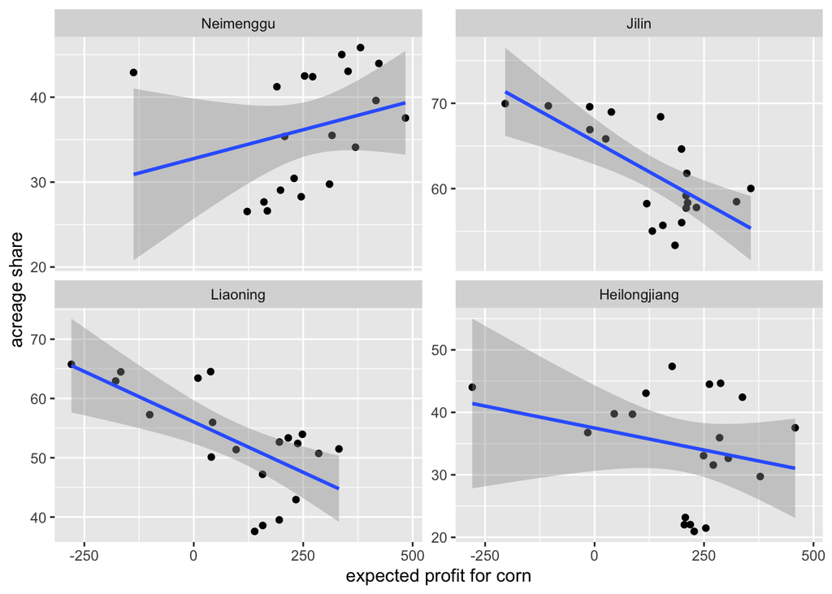

```r
ggplot(aes(x = pfex_corn, y = share), data = regdat %>% filter(crop == "corn")) + geom_point() +
  geom_smooth(method = "lm") +
  facet_wrap(~region, nrow = 2, scales = "free_y")+
  labs(x = "expected profit for corn", y = "acreage share")
```

2. Expected revenue against acreage share:

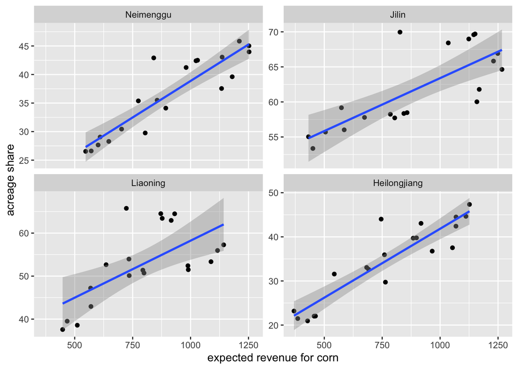

```r
ggplot(aes(x = revex_corn, y = share), data = regdat %>% filter(crop == "corn")) + geom_point() +
  geom_smooth(method = "lm") +
  facet_wrap(~region, nrow = 2, scales = "free_y")+
  labs(x = "expected revenue for corn", y = "acreage share")
```

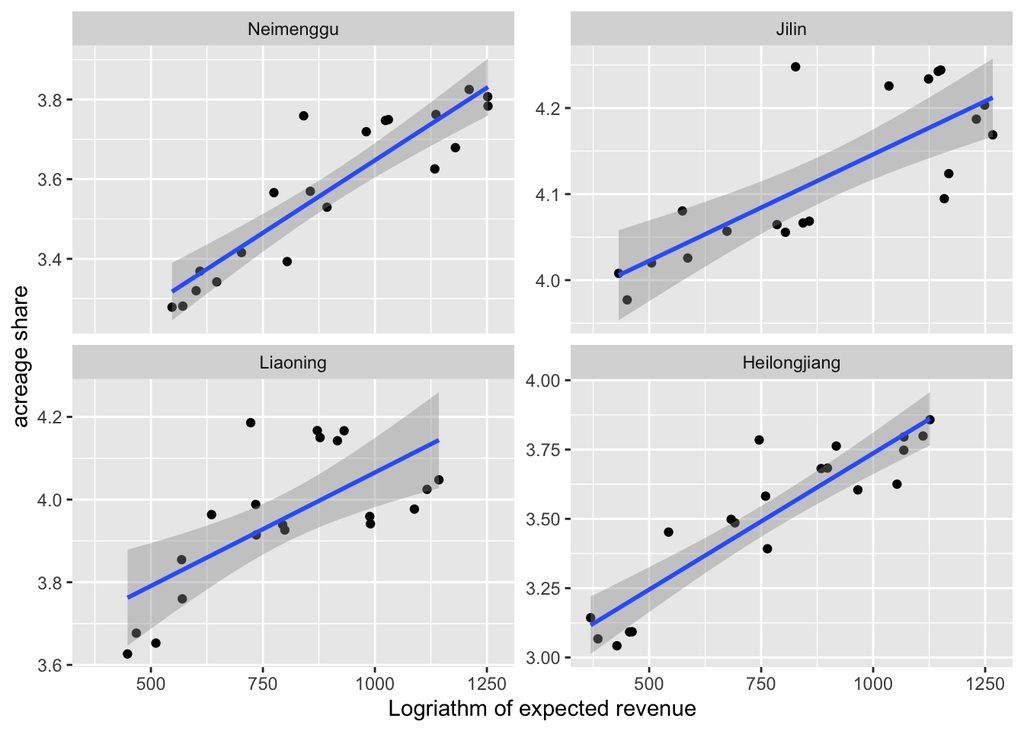

```r
ggplot(aes(x = revex_corn, y = log(share)), data = regdat %>% filter(crop == "corn")) + geom_point() +
  geom_smooth(method = "lm") +
  facet_wrap(~region, nrow = 2, scales = "free_y")+
  labs(x = "Logriathm of expected revenue", y = "acreage share")
```

#### Model 1 Regression

```r
lm_corn_pf <- lm(y ~ 0 + pfex_corn + pfex_rice + pfex_soy + pfex_wheat + region,
              data = regdat %>% filter(crop == "corn"))

lm_rice_pf <- lm(y ~ 0 + pfex_corn + pfex_rice + pfex_soy + pfex_wheat + region,
              data = regdat %>% filter(crop == "rice"))

lm_soy_pf <- lm(y ~ 0 + pfex_corn + pfex_rice + pfex_soy + pfex_wheat + region,
              data = regdat %>% filter(crop == "soybean"))

lm_wheat_pf <- lm(y ~ 0 + pfex_corn + pfex_rice + pfex_soy + pfex_wheat + region,
              data = regdat %>% filter(crop == "wheat"))
#summary(lm_corn_pf)
#summary(lm_rice_pf)
#summary(lm_soy_pf)
#summary(lm_wheat_pf)
stargazer(lm_corn_pf, lm_rice_pf, lm_soy_pf, lm_wheat_pf, title = "Model 1 Results",column.labels = c("Corn", "Rice", "Soybean", "Wheat"), type = "text", digit = 3, dep.var.caption  = "")
```

```
##
## Model 1 Results
## ========================================================================
##                                                   y
##                                 Corn       Rice     Soybean     Wheat
##                                  (1)       (2)        (3)        (4)
## ------------------------------------------------------------------------
## pfex_corn                      -0.0005    -0.001     -0.001     0.001
##                               (0.0004)   (0.0004)   (0.0004)   (0.001)
##
## pfex_rice                     -0.001*** -0.001***   0.00002    0.001***
##                               (0.0001)   (0.0001)   (0.0001)   (0.0002)
##
## pfex_soy                       0.0003     0.0003    0.001**     0.001
##                               (0.0004)   (0.0005)   (0.001)    (0.001)
##
## pfex_wheat                     0.0004     0.001*     0.001     -0.0002
##                               (0.0005)   (0.001)    (0.001)    (0.001)
##
## regionNeimenggu               0.493***  -2.937***  -1.312***  -2.418***
##                                (0.134)   (0.142)    (0.154)    (0.244)
##
## regionJilin                   1.816***    0.019    -1.230***  -5.911***
##                                (0.108)   (0.115)    (0.124)    (0.197)
##
## regionLiaoning                1.306***    -0.157   -2.078***  -5.432***
##                                (0.105)   (0.112)    (0.121)    (0.192)
##
## regionHeilongjiang            1.699***   0.996***   0.857***  -2.624***
##                                (0.111)   (0.118)    (0.128)    (0.202)
##
## ------------------------------------------------------------------------
## Observations                     80         80         80         80
## R2                              0.901     0.966      0.938      0.978
## Adjusted R2                     0.890     0.963      0.931      0.975
## Residual Std. Error (df = 72)   0.340     0.361      0.390      0.619
## F Statistic (df = 8; 72)      82.015*** 258.523*** 136.528*** 399.086***
## ========================================================================
## Note:                                        *p<0.1; **p<0.05; ***p<0.01
##
## Model 1 Results
## =
## 3
## -
```

#### Model 2 Regression

```r
lm_corn_rev <- lm(y ~ 0 + revex_corn + revex_rice + revex_soy + revex_wheat  + region,
              data = regdat %>% filter(crop == "corn"))

lm_rice_rev <- lm(y ~ 0 + revex_corn + revex_rice + revex_soy + revex_wheat + region,
              data = regdat %>% filter(crop == "rice"))

lm_soy_rev <- lm(y ~ 0 + revex_corn + revex_rice + revex_soy + revex_wheat  + region,
              data = regdat %>% filter(crop == "soybean"))

lm_wheat_rev <- lm(y ~ 0 + revex_corn + revex_rice + revex_soy + revex_wheat  + region,
              data = regdat %>% filter(crop == "wheat"))

stargazer(lm_corn_rev, lm_rice_rev, lm_soy_rev, lm_wheat_rev, title = "Model 2 Results",column.labels = c("Corn", "Rice", "Soybean", "Wheat"), type = "text", digit = 3, dep.var.caption  = "")
```

```
##
## Model 2 Results
## ========================================================================
##                                                   y
##                                 Corn       Rice     Soybean     Wheat
##                                  (1)       (2)        (3)        (4)
## ------------------------------------------------------------------------
## revex_corn                      0.001     0.0004    -0.0003    -0.0004
##                               (0.0004)   (0.0004)   (0.0005)   (0.001)
##
## revex_rice                    0.001***   0.001**    0.001**    -0.0003
##                               (0.0004)   (0.0004)   (0.0005)   (0.001)
##
## revex_soy                       0.001     0.001      0.001      -0.002
##                                (0.001)   (0.001)    (0.001)    (0.001)
##
## revex_wheat                    0.001**    0.001     -0.0003     0.0002
##                               (0.0005)   (0.001)    (0.001)    (0.001)
##
## regionNeimenggu               -4.362*** -6.576***  -2.896***    -0.373
##                                (0.775)   (0.850)    (0.929)    (1.543)
##
## regionJilin                   -2.789*** -3.347***  -2.807***   -3.663**
##                                (0.759)   (0.832)    (0.910)    (1.511)
##
## regionLiaoning                -3.774*** -3.948***  -3.844***   -3.197*
##                                (0.807)   (0.885)    (0.967)    (1.606)
##
## regionHeilongjiang            -2.668*** -2.184***    -0.644     -0.567
##                                (0.714)   (0.783)    (0.856)    (1.420)
##
## ------------------------------------------------------------------------
## Observations                     80         80         80         80
## R2                              0.910     0.967      0.939      0.976
## Adjusted R2                     0.901     0.964      0.932      0.974
## Residual Std. Error (df = 72)   0.323     0.355      0.388      0.644
## F Statistic (df = 8; 72)      91.522*** 267.781*** 138.425*** 368.499***
## ========================================================================
## Note:                                        *p<0.1; **p<0.05; ***p<0.01
##
## Model 2 Results
## =
## 3
## -
```

```r
#summary(lm_corn_rev)
#summary(lm_rice_rev)
#summary(lm_soy_rev)
#summary(lm_wheat_rev)
```

#### Model 3 Regression

```r
lm_corn_rr <- lm(y ~ 0 + rr_corn + rr_rice + rr_soy + region, # rc_corn + rc_rice + rc_soy +
              data = regdat %>% filter(crop == "corn"))

lm_rice_rr <- lm(y ~ 0 + rr_corn + rr_rice + rr_soy + region,
              data = regdat %>% filter(crop == "rice"))

lm_soy_rr <- lm(y ~ 0 +  rr_corn + rr_rice + rr_soy +  region,
              data = regdat %>% filter(crop == "soybean"))

lm_wheat_rr <- lm(y ~ 0 +  rr_corn + rr_rice + rr_soy +  region,
              data = regdat %>% filter(crop == "wheat"))

stargazer(lm_corn_rr, lm_rice_rr, lm_soy_rr, lm_wheat_rr, title = "Model 3 Results",column.labels = c("Corn", "Rice", "Soybean", "Wheat"), type = "text", digit = 3, dep.var.caption  = "")
```

```
##
## Model 3 Results
## ========================================================================
##                                                   y
##                                 Corn       Rice     Soybean     Wheat
##                                  (1)       (2)        (3)        (4)
## ------------------------------------------------------------------------
## rr_corn                         0.368     0.324      -0.311     -0.829
##                                (0.296)   (0.294)    (0.321)    (0.513)
##
## rr_rice                       -0.350*** -0.254***    0.017     0.269***
##                                (0.040)   (0.040)    (0.044)    (0.070)
##
## rr_soy                          0.384     0.138      0.581      -0.096
##                                (0.439)   (0.437)    (0.476)    (0.762)
##
## regionNeimenggu                -0.012   -3.341***  -1.422***  -1.443***
##                                (0.271)   (0.270)    (0.294)    (0.471)
##
## regionJilin                   1.404***    -0.112   -1.306***  -4.934***
##                                (0.392)   (0.390)    (0.425)    (0.680)
##
## regionLiaoning                0.830***   -0.468*   -2.227***  -4.660***
##                                (0.281)   (0.279)    (0.305)    (0.487)
##
## regionHeilongjiang            1.371***   0.901***   0.767**   -1.761***
##                                (0.335)   (0.333)    (0.364)    (0.581)
##
## ------------------------------------------------------------------------
## Observations                     80         80         80         80
## R2                              0.883     0.965      0.935      0.976
## Adjusted R2                     0.872     0.962      0.928      0.974
## Residual Std. Error (df = 73)   0.367     0.365      0.398      0.636
## F Statistic (df = 7; 73)      78.822*** 288.269*** 149.405*** 430.786***
## ========================================================================
## Note:                                        *p<0.1; **p<0.05; ***p<0.01
##
## Model 3 Results
## =
## 3
## -
```

```r
#summary(lm_corn_rr)
#summary(lm_rice_rr)
#summary(lm_soy_rr)
#summary(lm_wheat_rr)
```

#### Prediction Results

True Result in 2021

```r
share_true %>% data.frame() %>% "colnames<-"(unique(regdat$region)) %>%
  "rownames<-"(unique(regdat$crop)) %>% pander::pander()
```

|  | Neimenggu | Jilin | Liaoning | Heilongjiang |
| --- | --- | --- | --- | --- |
| **corn** | 48.09 | 71.14 | 62.93 | 43.31 |
| **rice** | 1.77 | 13.53 | 12.03 | 25.67 |
| **soybean** | 10.22 | 4.08 | 2.4 | 25.81 |
| **wheat** | 5.06 | 0.07 | 0.06 | 0.45 |

Model 1 Prediction

```r
share_est_pf %>% data.frame() %>% "colnames<-"(unique(regdat$region)) %>%
  "rownames<-"(unique(regdat$crop)) %>% pander::pander()
```

|  | Neimenggu | Jilin | Liaoning | Heilongjiang |
| --- | --- | --- | --- | --- |
| **corn** | 43.26 | 68.81 | 62.04 | 43.66 |
| **rice** | 1.45 | 12.37 | 15.22 | 22.58 |
| **soybean** | 9.66 | 4.85 | 3.25 | 23.33 |
| **wheat** | 7.64 | 0.06 | 0.15 | 1 |

Model 2 Prediction

```r
share_est_rev %>% data.frame() %>% "colnames<-"(unique(regdat$region)) %>%
  "rownames<-"(unique(regdat$crop)) %>% pander::pander()
```

|  | Neimenggu | Jilin | Liaoning | Heilongjiang |
| --- | --- | --- | --- | --- |
| **corn** | 56.49 | 73.76 | 67.52 | 46.33 |
| **rice** | 1.72 | 13.1 | 14.74 | 24.68 |
| **soybean** | 7.43 | 3.7 | 2.61 | 21.48 |
| **wheat** | 2.49 | 0.02 | 0.05 | 0.37 |

Model 3 Prediction

```r
share_est_rr %>% data.frame() %>% "colnames<-"(unique(regdat$region)) %>%
  "rownames<-"(unique(regdat$crop)) %>% pander::pander()
```

|  | Neimenggu | Jilin | Liaoning | Heilongjiang |
| --- | --- | --- | --- | --- |
| **corn** | 48.71 | 71.74 | 60.2 | 45.64 |
| **rice** | 1.57 | 12.84 | 14.4 | 23.63 |
| **soybean** | 9.09 | 3.98 | 3.21 | 22.23 |
| **wheat** | 3.73 | 0.03 | 0.13 | 0.56 |

#### MSE Results

```r
MSE1 <- rowMeans((share_true - share_est_pf)^2)
MSE2 <- rowMeans((share_true - share_est_rev)^2)
MSE3 <- rowMeans((share_true - share_est_rr)^2)

cbind(MSE1, MSE2, MSE3) %>% "colnames<-"(paste0("Model", 1:3)) %>%
  "rownames<-"(unique(regdat$crop)) %>% pander::pander()
```

|  | Model1 | Model2 | Model3 |
| --- | --- | --- | --- |
| **corn** | 7.418 | 26.9 | 3.407 |
| **rice** | 5.293 | 2.128 | 2.574 |
| **soybean** | 1.945 | 6.68 | 3.69 |
| **wheat** | 1.742 | 1.653 | 0.4469 |